# Logistic Regression

The purpose of this chapter is to get familiar with the logistic regression.

## Data description

I’m going to use a dataset of **Student alcohol consumption** from UCI Machine Learning Repository. The purpose of the original data have been to predict secondary school student alcohol comsumption in Portugal. This material contains two separate datasets of math and Portuguese language courses but to note that the questionnaires have been identical. There are also students who have answered both questionnaires.

=====================================

**You can find more detailed information about those two datasets** [here](https://archive.ics.uci.edu/ml/datasets/STUDENT+ALCOHOL+CONSUMPTION).

**Data reference**: Using Data Mining To Predict Secondary School Student Alcohol Consumption. Fabio Pagnotta, Hossain Mohammad Amran. Department of Computer Science,University of Camerino.

======================================

**In this analysis** the purpose is to use combined datset where we have those students who have answered these two questionnaires i.e. students who have participated both in the math and the Portuguese language courses. To combine the two datasets we have utilized some of the backround questions including:

- school (student’s school: GB - Gabriel Pereira or MS - Mousinho da Silveira)
- sex (F - female or M - male)
- age (student’s age: from 15 to 22)
- address (U - urban or R - rural)
- famsize (family size: LE3 - less or equal to 3 or GT3 - greater than 3)
- Pstatus (parent’s cohabitation status: T - living together or A - apart)
- Medu (mother’s education: 0 - none, 1 - primary education (4th grade), 2 - 5th to 9th grade, 3 - secondary education or 4 - higher education)
- Fedu (father’s education: 0 - none, 1 - primary education (4th grade), 2 - 5th to 9th grade, 3 - secondary education or 4 - higher education)
- Mjob (mother’s job: ‘teacher’, ‘health’ care related, civil ‘services’ (e.g. administrative or police), ‘at_home’ or ‘other’)
- Fjob (father’s job: ‘teacher’, ‘health’ care related, civil ‘services’ (e.g. administrative or police), ‘at_home’ or ‘other’)
- reason (reason to choose this school: close to ‘home’, school ‘reputation’, ‘course’ preference or ’other)
- nursery (attended nursery school: yes or no)
- internet (Internet access at home: yes or no)

======================================

**You can find the dataset which is utilized in this analysis** [here](http://s3.amazonaws.com/assets.datacamp.com/production/course_2218/datasets/alc.txt).

======================================

**Underneath you can see all the variables of the combined dataset** consisting 382 observations and 35 variables.

The following adjustments have also been made: The variables not used for joining the two data have been combined by averaging (including the grade variables). “alc_use”" is the average of “Dalc” (workday alcohol consumption) and “Walc” (weekend alcohol consumption). “high_use”" is TRUE if “alc_use” is higher than 2 and the scale ranges between 1 and 5 (from 1 - very low to 5 - very high).

```r
joined_alcohol <- read.table("http://s3.amazonaws.com/assets.datacamp.com/production/course_2218/datasets/alc.txt", sep = ",", header = TRUE)
```

**NAMES OF DATA VARIABLES**

```r
colnames(joined_alcohol)
```

```
##  [1] "school"     "sex"        "age"        "address"    "famsize"
##  [6] "Pstatus"    "Medu"       "Fedu"       "Mjob"       "Fjob"
## [11] "reason"     "nursery"    "internet"   "guardian"   "traveltime"
## [16] "studytime"  "failures"   "schoolsup"  "famsup"     "paid"
## [21] "activities" "higher"     "romantic"   "famrel"     "freetime"
## [26] "goout"      "Dalc"       "Walc"       "health"     "absences"
## [31] "G1"         "G2"         "G3"         "alc_use"    "high_use"
```

**Underneath you can take a closer look at the content of the data variables.** The variables which i haven’t introduce yet includes:

- guardian (student’s guardian: ‘mother’, ‘father’ or ‘other’)
- traveltime (home to school travel time: 1 - <15 min., 2 - 15 to 30 min., 3 - 30 min. to 1 hour, or 4 - >1 hour)
- studytime (weekly study time: 1 - <2 hours, 2 - 2 to 5 hours, 3 - 5 to 10 hours, or 4 - >10 hours)
- failures (number of past class failures: n if 1 <= n < 3, else 4)
- schoolsup (extra educational support: yes or no)
- famsup (family educational support: yes or no)
- paid (extra paid classes within the course subject (Math or Portuguese): yes or no)
- activities (extra-curricular activities: yes or no)
- higher (wants to take higher education: yes or no)
- romantic (with a romantic relationship: yes or no)
- famrel (quality of family relationships: from 1 - very bad to 5 - excellent)
- freetime (free time after school: from 1 - very low to 5 - very high)
- goout (going out with friends: from 1 - very low to 5 - very high)
- Dalc (workday alcohol consumption: from 1 - very low to 5 - very high)
- Walc (weekend alcohol consumption: from 1 - very low to 5 - very high)
- health (current health status: from 1 - very bad to 5 - very good)
- absences (number of school absences: from 0 to 93)
- G1 (first period grade: from 0 to 20)
- G2 (second period grade: from 0 to 20)
- G3 (final grade: from 0 to 20, output target)

**STRUCTURE OF THE DATA VARIABLES**

```r
str(joined_alcohol)
```

```
## 'data.frame':    382 obs. of  35 variables:
##  $ school    : Factor w/ 2 levels "GP","MS": 1 1 1 1 1 1 1 1 1 1 ...
##  $ sex       : Factor w/ 2 levels "F","M": 1 1 1 1 1 2 2 1 2 2 ...
##  $ age       : int  18 17 15 15 16 16 16 17 15 15 ...
##  $ address   : Factor w/ 2 levels "R","U": 2 2 2 2 2 2 2 2 2 2 ...
##  $ famsize   : Factor w/ 2 levels "GT3","LE3": 1 1 2 1 1 2 2 1 2 1 ...
##  $ Pstatus   : Factor w/ 2 levels "A","T": 1 2 2 2 2 2 2 1 1 2 ...
##  $ Medu      : int  4 1 1 4 3 4 2 4 3 3 ...
##  $ Fedu      : int  4 1 1 2 3 3 2 4 2 4 ...
##  $ Mjob      : Factor w/ 5 levels "at_home","health",..: 1 1 1 2 3 4 3 3 4 3 ...
##  $ Fjob      : Factor w/ 5 levels "at_home","health",..: 5 3 3 4 3 3 3 5 3 3 ...
##  $ reason    : Factor w/ 4 levels "course","home",..: 1 1 3 2 2 4 2 2 2 2 ...
##  $ nursery   : Factor w/ 2 levels "no","yes": 2 1 2 2 2 2 2 2 2 2 ...
##  $ internet  : Factor w/ 2 levels "no","yes": 1 2 2 2 1 2 2 1 2 2 ...
##  $ guardian  : Factor w/ 3 levels "father","mother",..: 2 1 2 2 1 2 2 2 2 2 ...
```

[output cut: 21 more lines]

## My initial hypotheses

The purpose of this analysis is to study the relationships between high/low alcohol consumption and 4 variables of my own interest in the data. I think there are many interesting variables which might have the relationship with the alcohol consumption.

**HYPOTHESIS 1**

First variable will be **sex** i.e. female or male. I believe the gender has a relationship with alcohol consumption but it is impossible to say which gender type has a bigger probability to be a “high user” or “low user”. One of the reasons are that I’m unfamiliar with the culture of Portugal and their habits of alcohol consumption.

**HYPOTHESIS 2**

The second interesting variable will be the weekly **studytime** which has the possible outcomes of 1 (less than 2 hours), 2 (2 to 5 hours), 3 (5 to 10 hours) or 4 (more than 10 hours).

I believe that the weekly studytime and alcohol consumption have a relationship in the way that the less a student studies the bigger is the probability to be an alcohol “high user” and vice versa.

**HYPOTHESIS 3**

The third variable which I’m going to choose is **goout** as going out with friends. This variable has the possible values from 1 (very low) to 5 (very high).

The variable of going out with friends doesn’t tell us which kind of activities it consists but I believe that the more one goes out the bigger probability is to use alcohol. That is the more the student goes out the greater might be the probability to be an alcohol “high user” and vice versa.

**HYPOTHESIS 4**

The last variable which interest me is **famrel** as quality of family relationships which ranges from 1 (very bad) to 5 (excellent).

I believe there can be a relationship between family relationships and alcohol consumption in such a way that the worse these relationships are the bigger is the probability to be a “high user” of alcohol. Of course in a bigger picture the other relevant aspect could be the overall importance of these family relationships which can define if these relationships affect to the student’s alcohol consumption at all.

## Relationships between the variables in terms of my initial hypotheses

In this section I’m going to explore the distributions of the variables which were introduced in the previous chapter. The second purpose is to explore the possible relationships between alcohol consumption and the chosen variables.

```r
library(tidyr); library(dplyr); library(ggplot2); library(knitr)
```

**SEX AND ALCOHOL CONSUMPTION**.

As you can see from the table below there are 198 females and 184 males in the dataset thus the groups seem to be nearly same size. Furthermore there are 382 students in the dataset.

```r
sex <- joined_alcohol$sex
alc_use <- joined_alcohol$alc_use
high_use <- joined_alcohol$high_use
joined_alcohol %>% count(sex) %>% mutate(freq = n / sum(n) * 100)
```

```
## # A tibble: 2 × 3
##      sex     n     freq
##   <fctr> <int>    <dbl>
## 1      F   198 51.83246
## 2      M   184 48.16754
```

The table below is created to show the amount of students who have evaluated their alcohol consumption lower or exactly equal to 2 **OR** higher than 2. The former suggests that the high use of alcohol consumption is false and the latter implies that the high use is true. Remember that the scale varies from 1 (very low) to 5 (very high).

The table also compares the alcohol consumption between genders and it suggests that there are somewhat more “high users” among men (n = 71) than women (n = 41). Other way round the table suggests that there are somewhat more “low users” among women (n = 157) than men (n = 113. These results suggest that there could be a relationship between sex and alcohol consumption.

```r
joined_alcohol %>% count(sex, high_use) %>% mutate(freq = n / sum(n = 382) * 100)
```

```
## Source: local data frame [4 x 4]
## Groups: sex [2]
##
##      sex high_use     n     freq
##   <fctr>    <lgl> <int>    <dbl>
## 1      F    FALSE   157 41.09948
## 2      F     TRUE    41 10.73298
## 3      M    FALSE   113 29.58115
## 4      M     TRUE    71 18.58639
```

The first bar chart illustrates the alcohol consumption between genders wheras the second chart clarifies the high use of alcohol between genders. Thus you can see the same results as described above.

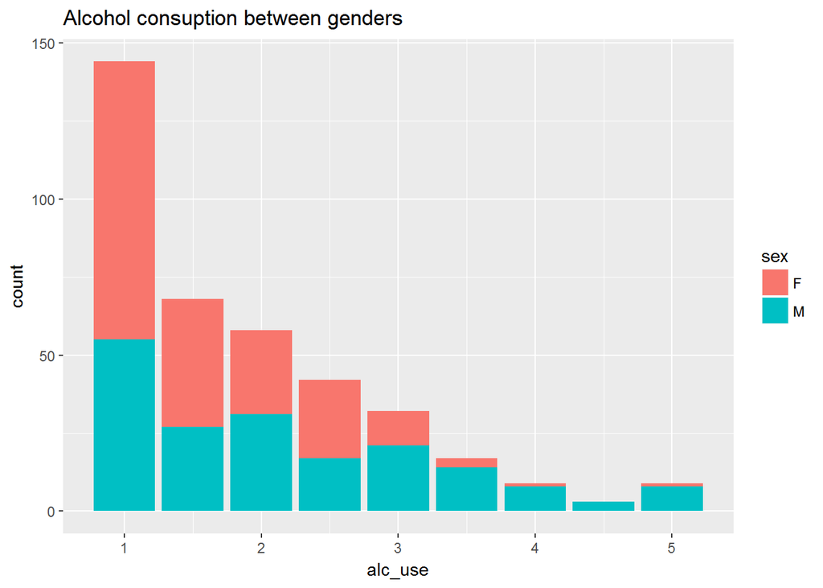

```r
g1 <- ggplot(data = joined_alcohol, aes(x = alc_use, fill = sex))
g1 + geom_bar() + ggtitle("Alcohol consuption between genders")
```

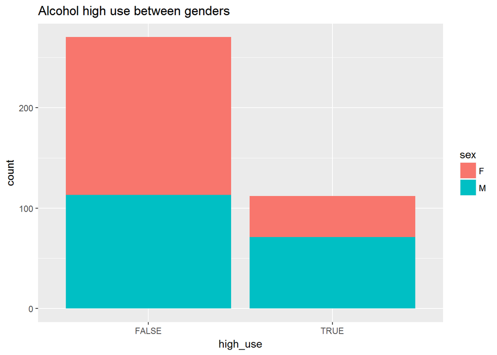

```r
g2 <- ggplot(data = joined_alcohol, aes(x = high_use, fill = sex))
g2 + geom_bar() + ggtitle("Alcohol high use between genders")
```

**WEEKLY STUDYTIME AND ALCOHOL CONSUMPTION**.

The first 3 tables illustrate the weekly studytime in general and between genders. To recall the measurement scale which ranges between 1 and 4, where

- 1 = less than 2 hours per week
- 2 = 2 to 5 hours per week
- 3 = 5 to 10 hours per week
- 4 = more than 10 hours per week

The first table discribes the total amount of studytime between students and as seen the popular studytime seems to vary from 2 to 5 hours per week considering the course. The same emphasis can be seen from the second table which indicates that the mean studytime is around 2 (2 to 5 hours per week).

The third table divides the mean of the studytime between genders and it suggests that female may spend more time to study than do males.

```r
studytime <- joined_alcohol$studytime
joined_alcohol %>% count(studytime) %>% mutate(freq = n / sum(n) * 100)
```

```
## # A tibble: 4 × 3
##   studytime     n      freq
##       <int> <int>     <dbl>
## 1         1   103 26.963351
## 2         2   190 49.738220
## 3         3    62 16.230366
## 4         4    27  7.068063
```

```r
summary(studytime)
```

```
##    Min. 1st Qu.  Median    Mean 3rd Qu.    Max.
##   1.000   1.000   2.000   2.034   2.000   4.000
```

```r
joined_alcohol %>% group_by(sex) %>% summarise(count = n(), mean = mean(studytime))
```

```
## # A tibble: 2 × 3
##      sex count     mean
##   <fctr> <int>    <dbl>
## 1      F   198 2.272727
## 2      M   184 1.777174
```

The table below is created to show the amount of students who have evaluated their alcohol consumption lower or exactly equal to 2 OR higher than 2. The former suggests that the high use of alcohol consumption is false and the latter implies that the high use is true. Remember that the scale varies from 1 (very low) to 5 (very high).

The table also compares the high use of alcohol between different amount of studytime. If you look at the frequencies (%), which are adjusted to count the percentages inside the unit of studytime, you can perceive that the frequencies of high use are somewhat lower inside the units of 3 and 4 and somewhat higher inside the units of 1 and 2. I think this may correspond with my hyothesis 2 where i suggested that the less a student studies the higher might be the probability to be a high user of alcohol.

```r
joined_alcohol %>% count(studytime, high_use) %>% mutate(freq = n / sum(n) * 100)
```

```
## Source: local data frame [8 x 4]
## Groups: studytime [4]
##
##   studytime high_use     n     freq
##       <int>    <lgl> <int>    <dbl>
## 1         1    FALSE    60 58.25243
## 2         1     TRUE    43 41.74757
## 3         2    FALSE   133 70.00000
## 4         2     TRUE    57 30.00000
## 5         3    FALSE    54 87.09677
## 6         3     TRUE     8 12.90323
## 7         4    FALSE    23 85.18519
## 8         4     TRUE     4 14.81481
```

The boxplot below compares the high alcohol consumption to students’ weekly studytime between genders.

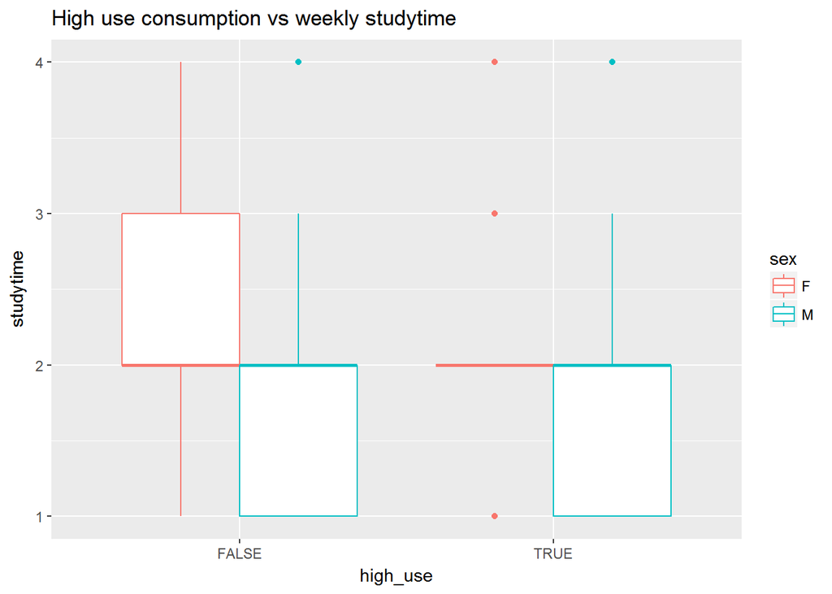

```r
g2 <- ggplot(data = joined_alcohol, aes(x = high_use, y = studytime, col = sex))
g2 + geom_boxplot() + ggtitle("High use consumption vs weekly studytime")
```

**GOING OUT WITH FRIENDS AND ALCOHOL CONSUMPTION**.

The first 3 tables illustrate the variable of going out with friends. The measurement scale varies between 1 (very low) and 5 (very high) and I assume that the scale means to count going out often or not so often.

The first table describes the total amounts of going out between students and the summary table indicates that the mean of going out is around 3.

The third table divides the mean of the going out between genders and it suggests that there might not be any differences between genders.

```r
goout <- joined_alcohol$goout
joined_alcohol %>% count(goout) %>% mutate(freq = n / sum(n) * 100)
```

```
## # A tibble: 5 × 3
##   goout     n      freq
##   <int> <int>     <dbl>
## 1     1    24  6.282723
## 2     2    99 25.916230
## 3     3   123 32.198953
## 4     4    82 21.465969
## 5     5    54 14.136126
```

```r
summary(goout)
```

```
##    Min. 1st Qu.  Median    Mean 3rd Qu.    Max.
##   1.000   2.000   3.000   3.113   4.000   5.000
```

```r
joined_alcohol %>% group_by(sex) %>% summarise(count = n(), mean = mean(goout))
```

```
## # A tibble: 2 × 3
##      sex count     mean
##   <fctr> <int>    <dbl>
## 1      F   198 3.045455
## 2      M   184 3.184783
```

The table below is created to show the amount of students who have evaluated their alcohol consumption lower or exactly equal to 2 OR higher than 2. The former suggests that the high use of alcohol consumption is false and the latter implies that the high use is true. Remember that the scale varies from 1 (very low) to 5 (very high).

The table compares the high use of alcohol between different frequencies (i.e. not going out often vs. going out often) of going out with friends. If you look at column of frequencies (%), which are adjusted to count the percentages inside the category of going out, you can perceive that the relative frequencies of alcohol high use are somewhat growing the more the student goes out with her/his friends. This may correspond with my hypothesis 3 where I suggested that the more the student goes out the greater might be the probability to be an alcohol high user and vice versa.

```r
joined_alcohol %>% count(goout, high_use) %>% mutate(freq = n / sum(n) * 100)
```

```
## Source: local data frame [10 x 4]
## Groups: goout [5]
##
##    goout high_use     n     freq
##    <int>    <lgl> <int>    <dbl>
## 1      1    FALSE    21 87.50000
## 2      1     TRUE     3 12.50000
## 3      2    FALSE    84 84.84848
## 4      2     TRUE    15 15.15152
## 5      3    FALSE   100 81.30081
## 6      3     TRUE    23 18.69919
## 7      4    FALSE    43 52.43902
## 8      4     TRUE    39 47.56098
## 9      5    FALSE    22 40.74074
## 10     5     TRUE    32 59.25926
```

The boxplot below compares the high alcohol consumption to frequency to go out with friends between genders.

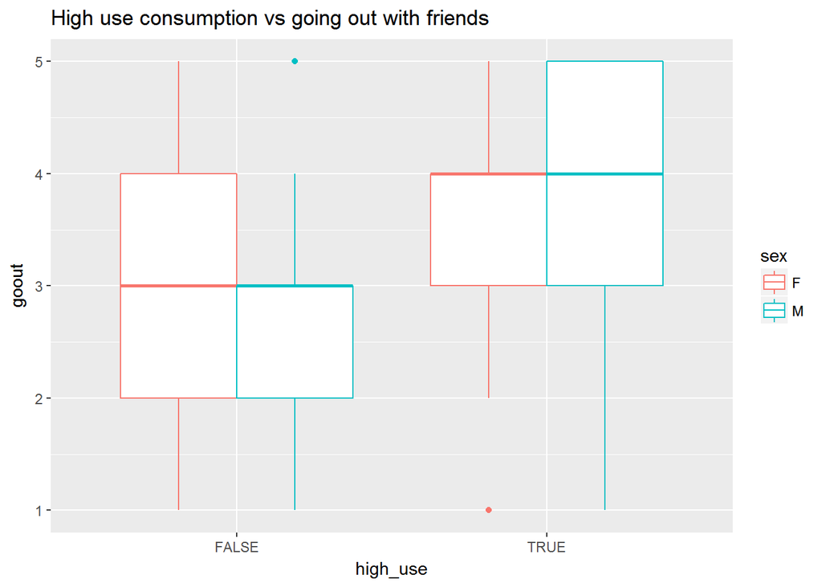

```r
g3 <- ggplot(data = joined_alcohol, aes(x = high_use, y = goout, col = sex))
g3 + geom_boxplot() + ggtitle("High use consumption vs going out with friends")
```

**FAMILY RELATIONSHIPS AND ALCOHOL CONSUMPTION**.

The first 3 tables illustrate the variable of quality of family relationships. This variable has been measured from 1 to 5 describing the family relationships to vary between very bad and excellent.

The third table divides the above mentioned mean on to categories of different genders. These results implies that there might not be any differences between genders considering the quality of family relationships.

```r
famrel <- joined_alcohol$famrel
joined_alcohol %>% count(famrel) %>% mutate(freq = n / sum(n) * 100)
```

```
## # A tibble: 5 × 3
##   famrel     n      freq
##    <int> <int>     <dbl>
## 1      1     9  2.356021
## 2      2    18  4.712042
## 3      3    66 17.277487
## 4      4   183 47.905759
## 5      5   106 27.748691
```

```r
summary(famrel)
```

```
##    Min. 1st Qu.  Median    Mean 3rd Qu.    Max.
##    1.00    4.00    4.00    3.94    5.00    5.00
```

```r
joined_alcohol %>% group_by(sex) %>% summarise(count = n(), mean = mean(famrel))
```

```
## # A tibble: 2 × 3
##      sex count     mean
##   <fctr> <int>    <dbl>
## 1      F   198 3.878788
## 2      M   184 4.005435
```

The table below is created to show the amount of students who have evaluated their alcohol consumption lower or exactly equal to 2 OR higher than 2. The former suggests that the high use of alcohol consumption is false and the latter implies that the high use is true. Remember that the scale varies from 1 (very low) to 5 (very high).

The table compares the high use of alcohol between different qualities of family relationships. Again the frequencies (%) have adjusted to count the percentages inside each category since in this way it is easier to compare relative frequencies between different quality categories.

It seems that high use is more common somewhere in the middle between bad and average kind of family relationships and the extreme values (very bad and excellent) don’t seem differ from eac other. Thus these results may not correspond with my hypothesis 4 where I suggested that the worse the relatioships are the higher is theprobability to be an alcohol high user.

```r
joined_alcohol %>% count(famrel, high_use) %>% mutate(freq = n / sum(n) * 100)
```

```
## Source: local data frame [10 x 4]
## Groups: famrel [5]
##
##    famrel high_use     n     freq
##     <int>    <lgl> <int>    <dbl>
## 1       1    FALSE     7 77.77778
## 2       1     TRUE     2 22.22222
## 3       2    FALSE     9 50.00000
## 4       2     TRUE     9 50.00000
## 5       3    FALSE    40 60.60606
## 6       3     TRUE    26 39.39394
## 7       4    FALSE   131 71.58470
## 8       4     TRUE    52 28.41530
## 9       5    FALSE    83 78.30189
## 10      5     TRUE    23 21.69811
```

The boxplot below compares the high alcohol consumption to qualities of family relationships between genders.

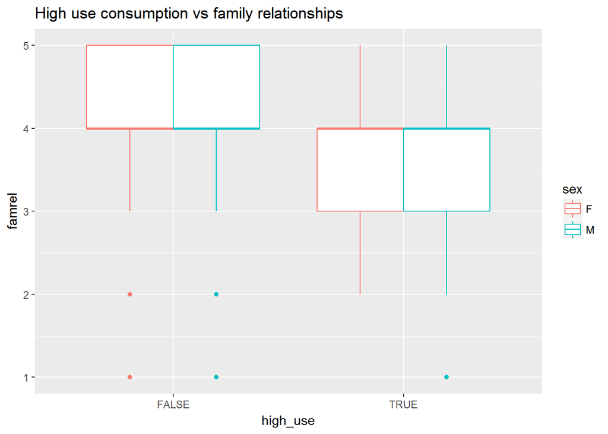

```r
g4 <- ggplot(data = joined_alcohol, aes(x = high_use, y = famrel, col = sex))
g4 + geom_boxplot() + ggtitle("High use consumption vs family relationships")
```

## Logistic regression model

In this chapter the purpose is to use logistic regression and find out if the previously chose variables are related to the high use of alcohol consumption and if the earlier suggested hypotheses can be considered as appropriate.

Before fitting the model I will inspect if there are any missing values in the combined data of alcohol consumption. The table below indicates that there are no missing values since the false is 13 370.

**TABLE OF THE MISSING VALUES**

```r
table(is.na(joined_alcohol))
```

```
##
## FALSE
## 13370
```

**SUMMARY OF THE FITTED MODEL**

My model contains both categorical (i.e. “sex”) and continuous variables (i.e. other variables) as independent variables.

First we can see that all the coefficients of independent variables are significant. The variable of the sex suggests a significant association of the sex of the student with the probability of the high use alcohol consumption. The positive coefficient for this predictor suggests that all other variables being equal, the male student is more likely to be a high user of alcohol compared to females. In my first hypothesis I suggested that the sex might have a relatioship with alcohol consumption but I couldn’t state if there are any differencies between genders.

Then we have the significant variable of weekly studytime suggesting an association of studytime with the probability of the high use of alcohol. The negative coefficient for this predictor implies that if the studytime increases, the probability (log odds) of being a high user of alcohol decreases if all other variables remain constant. This result corresponds with my second hypothesis where I suggested that the weekly studytime and alcohol consumption have a relationship in the way that the less a student studies the higher is the probability to be a high user and vice versa.

The variable of going out with friends (“goout”) has the lowest p-value suggesting a strong association of the going out with the probability of being an alcohol high user. The positive coefficient for the predictor suggests if one goes out more, the probability (log odds) of being a high user increases. This result is significant if all other variables remain constant. This corresponds with my third hypothesis where I suggested that the more the student goes out with her/his friends the higher may be the probability to be a high user and vice versa.

The last variable is the famrel which represents the quality of family relationhips. The significance of the factor suggests an association of the family relationships with the probability of being an alcohol high user. The negative coefficient implies that the better these relatinships are the higher is the probability (log odds) to be a low user of alcohol. Thus somewhat surprisingly this corresponds with fourth hypothesis. The surprising part comes from the chapter 3.3 after exploring the data structure of alcohol high use together with family relationships. After reading the summaries I started to doubt the possible relationship between these variables.

```r
my_model <- glm(high_use ~ sex + studytime + goout + famrel, data = joined_alcohol, family = "binomial")
summary(my_model)
```

```
##
## Call:
## glm(formula = high_use ~ sex + studytime + goout + famrel, family = "binomial",
##     data = joined_alcohol)
##
## Deviance Residuals:
##     Min       1Q   Median       3Q      Max
## -1.5928  -0.7494  -0.4919   0.8250   2.7080
##
## Coefficients:
##             Estimate Std. Error z value Pr(>|z|)
## (Intercept)  -1.2112     0.7142  -1.696  0.08991 .
## sexM          0.7593     0.2655   2.860  0.00424 **
## studytime    -0.4752     0.1703  -2.790  0.00527 **
## goout         0.7947     0.1218   6.523 6.89e-11 ***
## famrel       -0.4496     0.1379  -3.260  0.00111 **
## ---
## Signif. codes:  0 '***' 0.001 '**' 0.01 '*' 0.05 '.' 0.1 ' ' 1
##
## (Dispersion parameter for binomial family taken to be 1)
##
##     Null deviance: 462.21  on 381  degrees of freedom
## Residual deviance: 379.27  on 377  degrees of freedom
## AIC: 389.27
##
## Number of Fisher Scoring iterations: 4
```

**ODDS RATIOS**

Here the coefficients of the above regression model are exponentiated and therefore we can interpret them as odds-ratios (OR). Additionally the table below contain the confidence intervals (CI) of the odds-ratios.

```r
OR <- coef(my_model) %>% exp
CI <- confint(my_model) %>% exp
cbind(OR, CI)
```

```
##                    OR      2.5 %    97.5 %
## (Intercept) 0.2978484 0.07158146 1.1881189
## sexM        2.1368457 1.27450527 3.6171734
## studytime   0.6217330 0.44091699 0.8617913
## goout       2.2138196 1.75581193 2.8339395
## famrel      0.6378742 0.48488876 0.8343189
```

## The predictive power of my logistic model

```r
probabilities <- predict(my_model, type = "response")
joined_alcohol <- mutate(joined_alcohol, probability = probabilities)
joined_alcohol <- mutate(joined_alcohol, prediction = probability > 0.5)

table(high_use, prediction = probabilities > 0.5)
```

```
##         prediction
## high_use FALSE TRUE
##    FALSE   244   26
##    TRUE     66   46
```

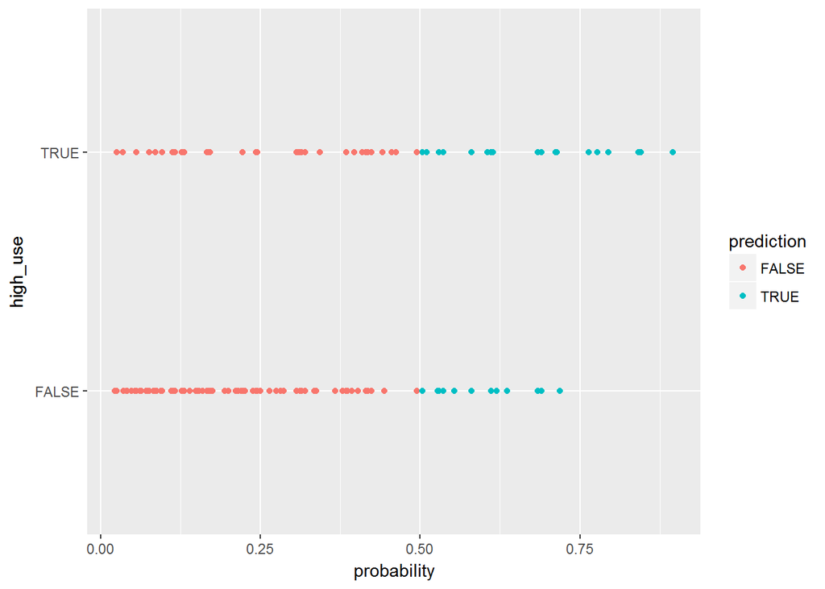

```r
library(dplyr)
g5 <- ggplot(joined_alcohol, aes(x = probability, y = high_use, col = prediction))
g5 + geom_point()
```

```r
table(high_use, prediction = joined_alcohol$prediction)
```

```
##         prediction
## high_use FALSE TRUE
##    FALSE   244   26
##    TRUE     66   46
```

```r
table(high_use, prediction = joined_alcohol$prediction) %>% prop.table()
```

```
##         prediction
## high_use      FALSE       TRUE
##    FALSE 0.63874346 0.06806283
##    TRUE  0.17277487 0.12041885
```